# Single-Cell Omics Research and Education

SCORE #5: Accessing KPMP Datasets

Jonathan Nelson and Xiao-Tong Su

30 June 2025

```r
library("dplyr")
library("Seurat")
library("knitr")
library("ggplot2")
library("BiocManager")
library("here")
#BiocManager::install("EnhancedVolcano")
library("EnhancedVolcano") #volcano plot
#install.packages('DESeq2') #for DEG
library("DESeq2")
library("tidyverse") #tidy up data
library("styler") #tidy up data
library("scCustomize") #for color scales)


if (!require("kableExtra")) {install.packages("kableExtra"); require("kableExtra")} # for color brewer
if (!require("RColorBrewer")) {install.packages("RColorBrewer"); require("RColorBrewer")} # for color brewer
if (!require("sctransform")) {install.packages("sctransform"); require("sctransform")} # for data normalization
if (!require("glmGamPoi")) {BiocManager::install('glmGamPoi'); require("glmGamPoi")} # for data normalization, sctransform
if (!require("cowplot")) {install.packages("cowplot"); require("cowplot")} # for figure layout
if (!require("patchwork")) {install.packages("patchwork"); require("patchwork")} # for figure patching
if (!require("openxlsx")) {install.packages("openxlsx"); require("openxlsx")} # to save .xlsx files

# install.packages("styler")



set.seed(12345)
# here()
```

# 1 Welcome

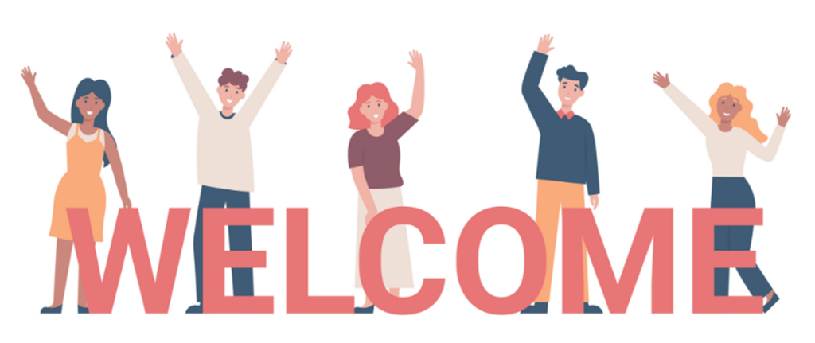

Welcome to the **Single-Cell Omics Research and Education Club**!

If this is your time to the club, **I want to extend and extra-special welcome to you!**

I’m **Jonathan Nelson**, an Assistant Professor at the University of Southern California. I’m a **wet** scientist turned **wet+dry** scientist. I’ve been working with **single-cell RNAseq data** for the past **5 years** and I’m excited to share what I’ve learned with you.

## 1.1 SCORE Values

### 1.1.1 **Learning**

We believe that bioinformatics is a constantly evolving field, and that ongoing learning and professional development is essential to staying up-to-date. We encourage members to share their knowledge and experiences with each other, and to seek out opportunities for continued learning.

### 1.1.2 **Accessibility**

We believe that access to bioinformatics support should be available to everyone. We strive to create a welcoming and inclusive environment where all members can feel comfortable asking for help and contributing to the group.

### 1.1.3 **Collaboration**

We believe that working together is key to achieving success in bioinformatics. We value the diversity of perspectives and backgrounds that each member brings, and we encourage open communication and the sharing of ideas.

### 1.1.4 **Integrity**

We believe in conducting ourselves with honesty and professionalism in all our interactions. We hold ourselves to high ethical standards and respect the privacy and confidentiality of all members.

### 1.1.5 **Empathy**

We believe in approaching each other with empathy and kindness. We understand that bioinformatics can be a challenging and sometimes frustrating field, and we strive to support each other through these difficulties.

## 1.2 Context and Expectations

I know a lot of this has been going on in the background for everyeone and I wanted to bring it to the forefront. **My expectation** is that we have **about 6 of these meetings** together and then we can re-evaluate if we want to continue as a group or not.

Email me you would like me to add anyone: **j.nelson@med.usc.edu**

Today’s code (**this html file**) will be posted to the SCORE website (https://usckrc.github.io/website/score.html)

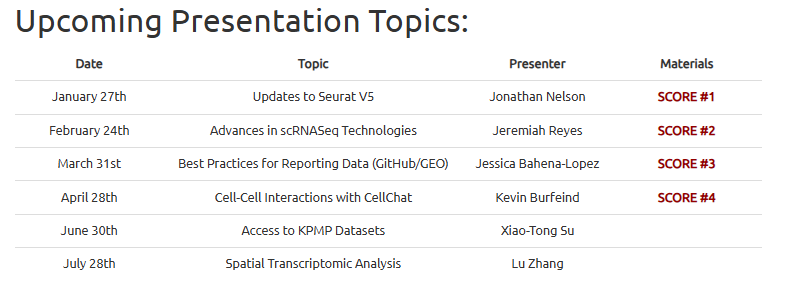

# 2 The Agenda!

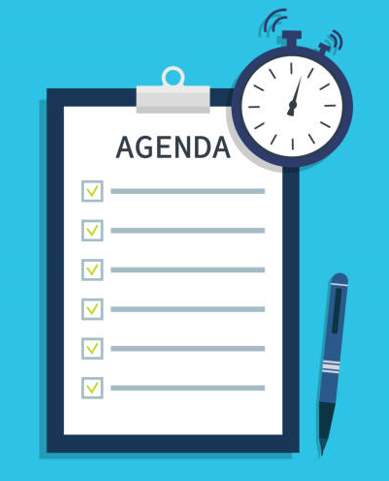

## 2.1 Music and Memes

## 2.2 Coding Crumbs: **renv package**

## 2.3 Recreating a Figure: **Stacked Violin Plot**

## 2.4 Main Theme: **Accessing KPMP Data**

# 3 Music and Memes

## 3.1 This Months Coding Music

### 3.1.1 **GIVĒON**: TAKE TIME

https://open.spotify.com/album/1zHR48K6XtWYm6bhrw4J6C?si=y4Jy1TloTuuRLYQLkyDgRg

[figure not shown]

### 3.1.2 Heartbreak Anniversay **Hits**

## 3.2 The Memes

### 3.2.1 **Not a strong month** for bioinfromatic memes

### 3.2.2 But I **hope** you enjoy these!

### 3.2.3 Meme 1: Periodic table of **“Can I lick it?”**

[figure not shown]

### 3.2.4 Meme 2: What goes into **Arxiv**

[figure not shown]

# 4 Coding Crumbs: **renv package**

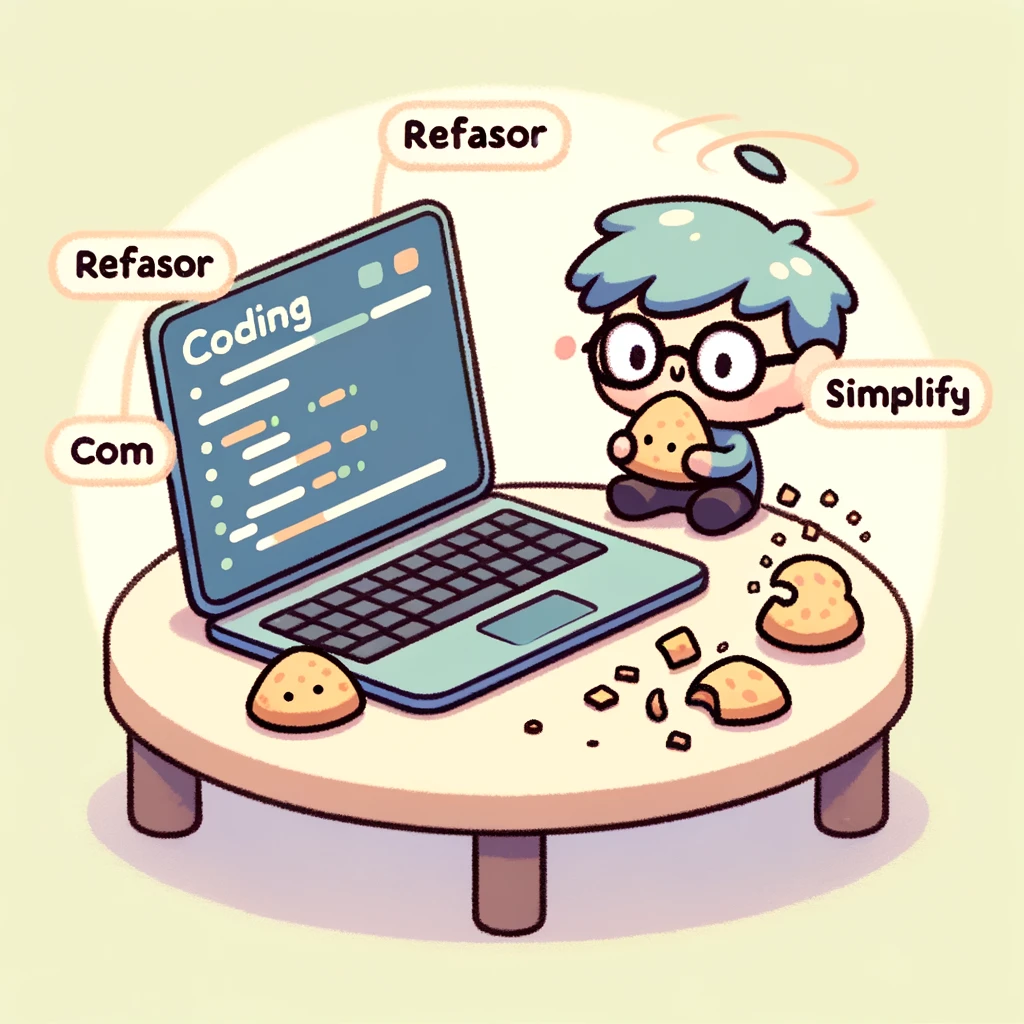

## 4.1 It **finally** happened!

### 4.1.1 I got too tired of **switching** between my Seurat v4 and Seurat v5 computers

#### 4.1.1.1 This was my solution for the Seurat v5

[figure not shown]

#### 4.1.1.2 Screenshot from **Score #1**

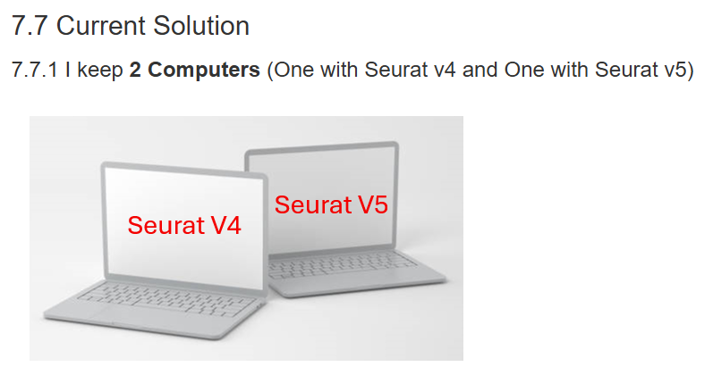

#### 4.1.1.3 Someone (Jesse Goodrich or Matt Salomon?) recommended trying out the *renv* package

## 4.2 What is renv?

[figure not shown]

https://rstudio.github.io/renv/articles/renv.html

### 4.2.1 A package for managing R project environments

### 4.2.2 Let’s be honest…we often get stuck in between projects as packages change

[figure not shown]

### 4.2.3 It allows you to create a **snapshot** of your R packages and versions

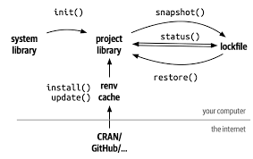

### 4.2.4 It allows you to **restore** your R packages and versions

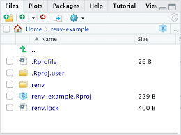

### 4.2.5 **Great** video from **Albert Rapp** on using renv

https://www.youtube.com/watch?v=Oen9xhEh8PY

[figure not shown]

### 4.2.6 It took me **5 minutes** to set this up on my system

### 4.2.7 I started by using the *renv* package in a new github repo that I was working on

### 4.2.8 **This easy!**

#### 4.2.8.1 Open up project from the folder where you want to use renv

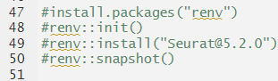

[figure not shown]

### 4.2.9 Now when I open the project from this location: **Seurat v5**

### 4.2.10 When I open project from any other folder: **Seurat v4**

## 4.3 **Take Home**

### 4.3.1 Implimenting *renv* is a great way to manage your R packages and versions

### 4.3.2 It’s been seamless and helped me to move between **Seurat v4** and **Seurat v5**

### 4.3.3 Important for making your code **reproducible!**

#### 4.3.3.1 Add a renv.lock file to your git repo so that others can use the same packages and versions

# 5 Recreating a Figure: **Stacked Violin Plot**

[figure not shown]

## 5.1 Final Product!

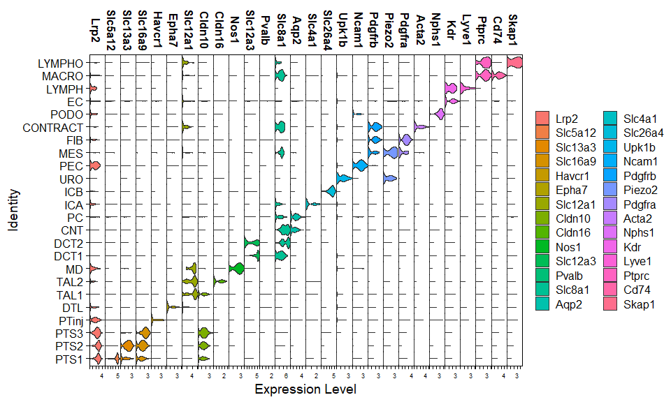

## 5.2 Publication Examples of Stacked Violin Plot

### 5.2.1 Figure 1 from Park et al. Science 2018

https://pubmed.ncbi.nlm.nih.gov/29622724/

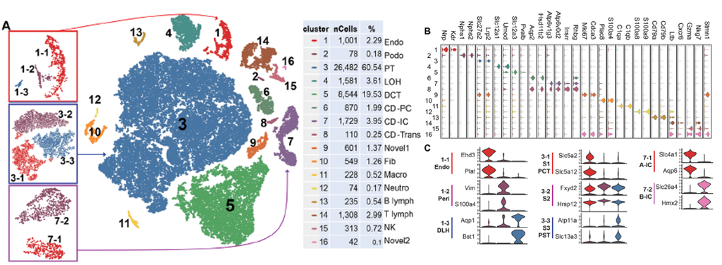

### 5.2.2 Figure 1 from Karaiskos et al. JASN 2018

https://pubmed.ncbi.nlm.nih.gov/29794128/

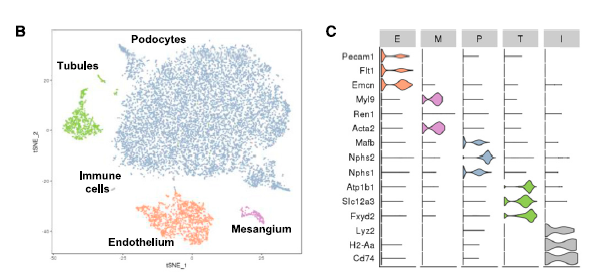

## 5.3 Start with a Seurat Object

### 5.3.1 Data from Figure 1 from Burfeind et al. Phys Genomics 2025

https://pubmed.ncbi.nlm.nih.gov/39982410/

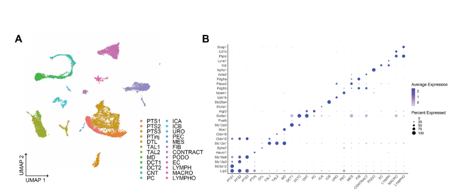

### 5.3.2 Load Dataset

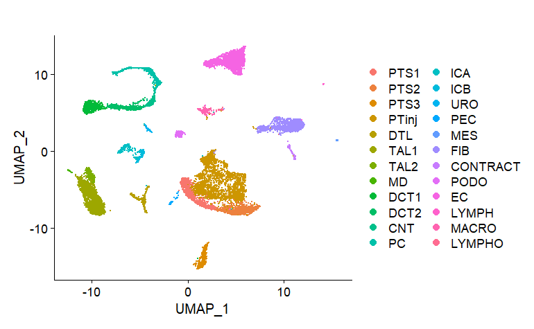

```r
SO <- readRDS(here("Week 4 CellChat", "data", "CACPR_integrated.rds"))

DimPlot(SO, group.by = "subclass.CACPR") + ggtitle("")

DefaultAssay(SO) <- "RNA"

SO@meta.data
```

### 5.3.3 Step 1: Create a list of genes

```r
markers.to.plot1 <- c("Lrp2",         # PT
                      "Slc5a12",      # PT-S1
                      "Slc13a3",      # PT-S2
                      "Slc16a9",      # PT-S3
                      "Havcr1",       # Injured PT
                      "Epha7",        # dTL
                      "Slc12a1",      # TAL
                      "Cldn10",       # TAL
                      "Cldn16",       # TAL
                      "Nos1",         # MD
                      "Slc12a3",      # DCT
                      "Pvalb",        # DCT1
                      "Slc8a1",       # DCT2, CNT
                      "Aqp2",         # PC
                      "Slc4a1",       # IC-A
                      "Slc26a4",      # IC-B
                      "Upk1b",        # Uro
                      "Ncam1",        # PEC
                      "Pdgfrb",       # Perivascular
                      "Piezo2",       # Mesangial
                      "Pdgfra",       # Fib
                      "Acta2",        # Mural
                      "Nphs1",        # Podo
                      "Kdr",          # Capillary Endo
                      "Lyve1",        # Lymph
                      "Ptprc",        # Immune
                      "Cd74",         # Macrophage
                      "Skap1"         # B/T Cells
                      )
```

### 5.3.4 Step 1b: Multidimentional Dotplot code

```r
DotPlot(SO,
features = markers.to.plot1,
dot.scale = 8,
dot.min = 0,
scale.max = 100,
scale.min = 0,
col.min = -2.5,
col.max = 2.5,
group.by = "class.CACPR") +
  coord_flip() +
  theme_classic() +
  theme(axis.line = element_line(size = 1, colour = "black"),
        axis.ticks.x = element_blank(),
        panel.grid.major.x = element_blank(),
        panel.grid.minor.x = element_blank(),
        panel.border = element_blank(),
        panel.background = element_blank(),
        text = element_text(size=20),
        axis.text.x = element_text(angle = 45, hjust = 1)) +
  xlab(NULL) +
  ylab(NULL)
```

[output not shown]

### 5.3.5 Step 2: Violin Plot of List in Features

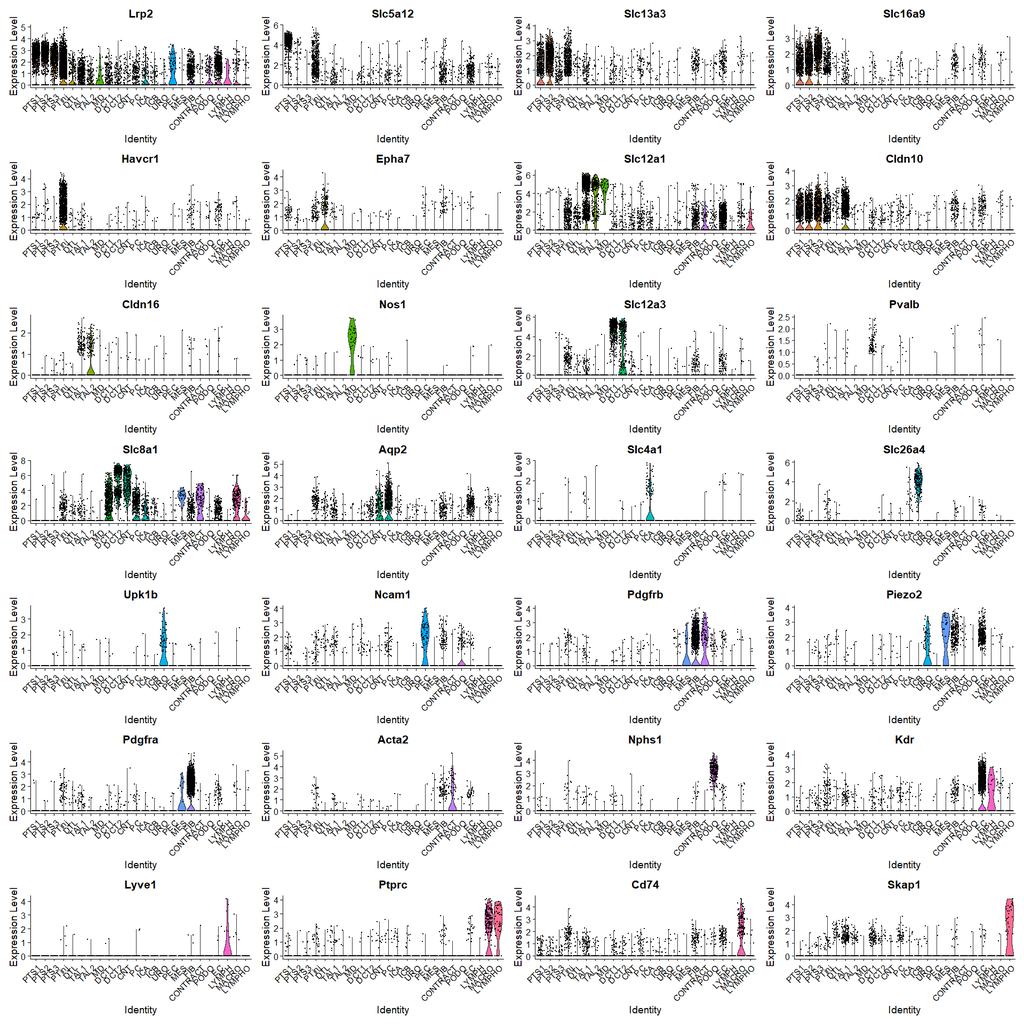

```r
VlnPlot(SO,
features = markers.to.plot1,
group.by = "subclass.CACPR")
```

#### 5.3.5.1 Looks really bad!

### 5.3.6 Step 3: Change the `stack =` argument

#### 5.3.6.1 **?VlnPlot**

#### 5.3.6.2 Gives you the modifiable arguements in the Vln Function

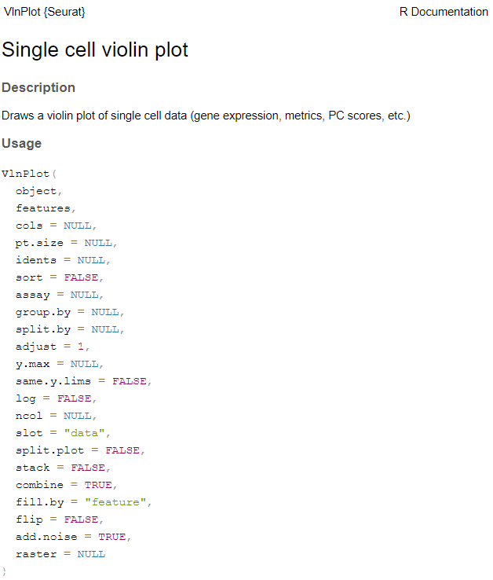

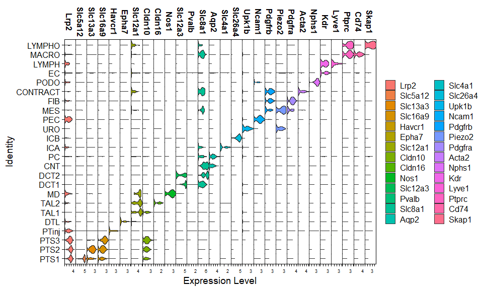

```r
VlnPlot(SO,
features = markers.to.plot1,
group.by = "subclass.CACPR",
stack = TRUE)  # This is the key argument to change
```

## 5.4 Lessons for Me

### 5.4.1 Sometimes creating graphs is as sample as knowing the *arguments* in a function

### 5.4.2 Still need to work on coloring by *subclass.CACPR* rather than *feature*

##### 5.4.2.0.1 Challenge for the next SCORE?

# 6 Main Theme: **Accessing KPMP Data**

## 6.1 The Kidney Precision Medicine Project

[figure not shown]

https://www.kpmp.org/

## 6.2 Manuscript Describing the Goals of KPMP

https://pubmed.ncbi.nlm.nih.gov/33637194/

[figure not shown]

### 6.2.1 Overarching Goals

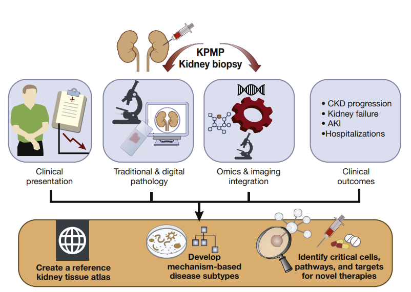

### 6.2.2 Patient Population

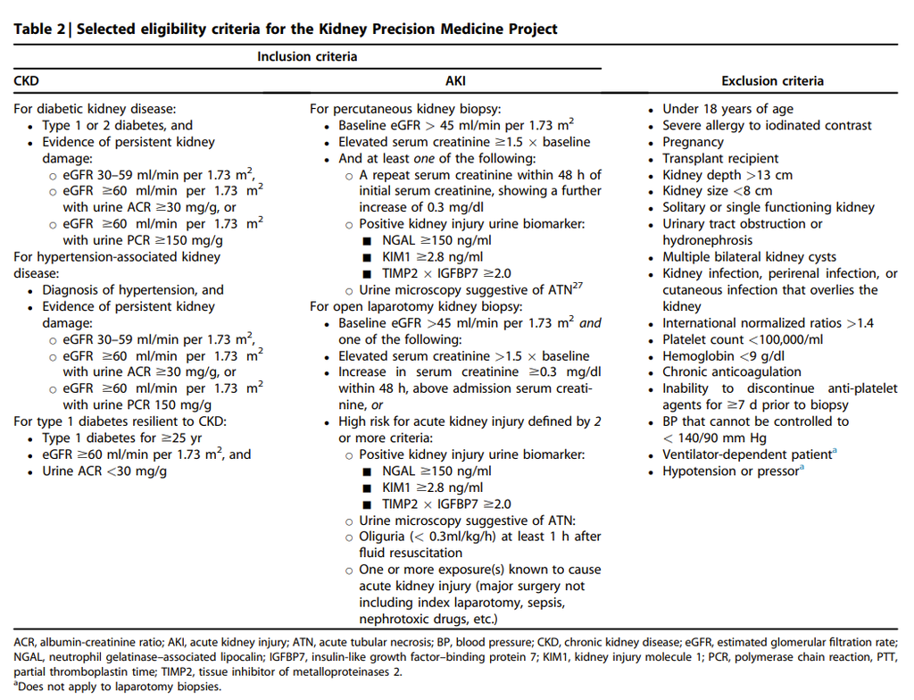

### 6.2.3 Tissue Handling

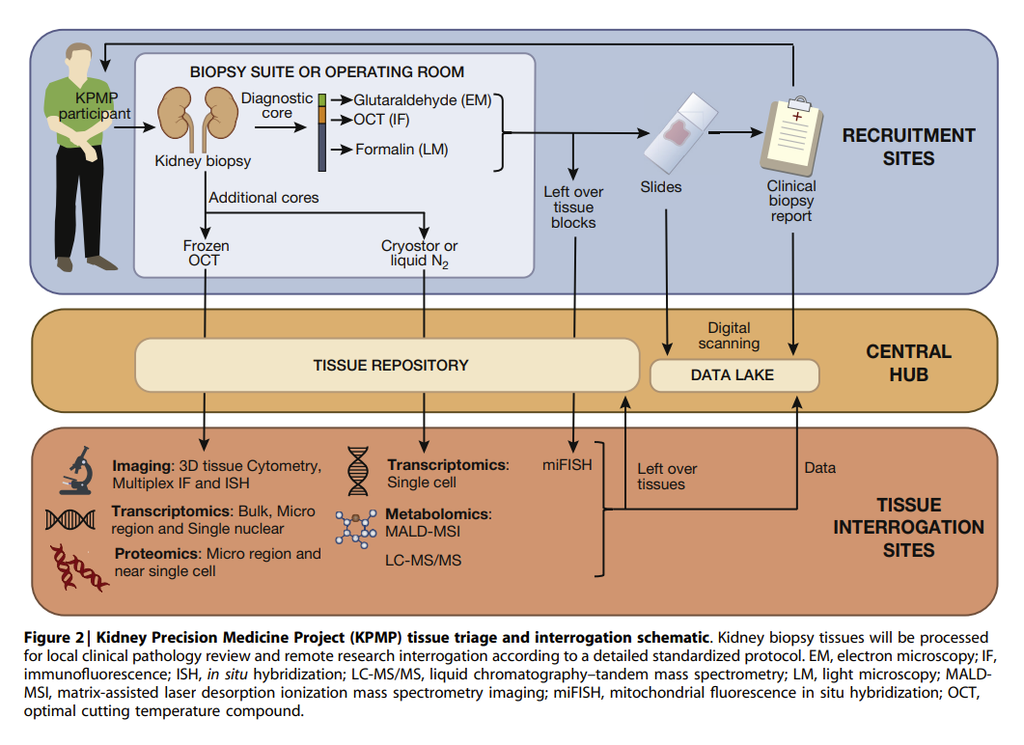

### 6.2.4 Outcomes

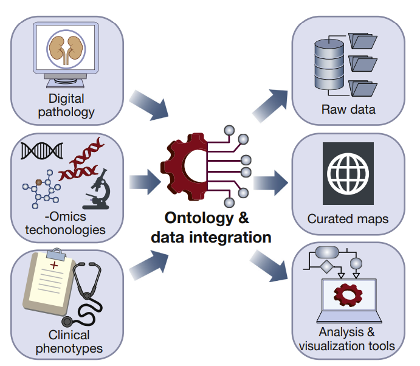

## 6.3 Atlas 1.0: Lake et al. Nature 2023

https://pubmed.ncbi.nlm.nih.gov/37468583/

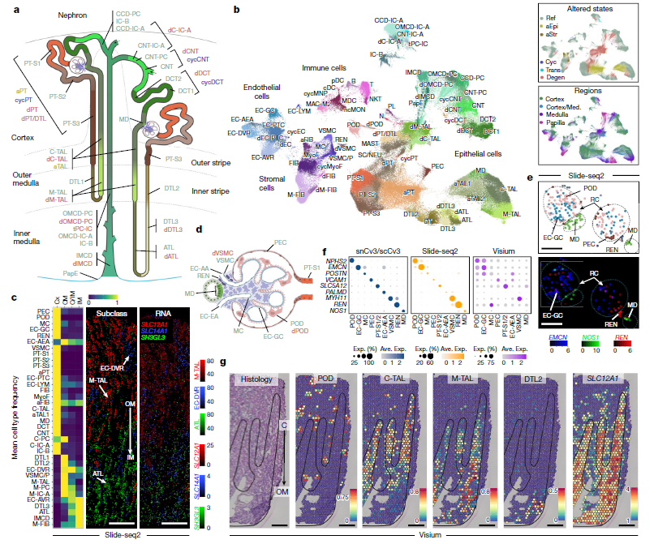